# 基于POI数据的北京市喜茶连锁店选址情况分析

案例背景： 近年来，国内现制茶饮行业迅猛发展，产生了如喜茶、乐乐茶、奈雪的茶等诸多知名品牌。而如何选址，对茶饮门店可谓是重中之重，它与门店全生命周期的经营发展密切相关。合适的选址可以让门店充分利用周边资源，带来高人流与成高交量；而选址有误却有可能让原本备受欢迎的茶饮品牌遇冷，甚至迎来关门闭店的结局。本案例以国内最知名的茶饮品牌之一喜茶为切入点，收集喜茶在北京市的门店以及周边POI数据，对喜茶连锁店在北京的选址展开研究。

这个案例的学习目标包括：

1、学习数据读入、数据清洗等数据预处理方法

2、学习描述分析、聚类分析等数据分析方法

3、学习数据分析与业务实际相结合的商业分析模式

## 准备工作

```python
from pyecharts.charts import Geo
from pyecharts import options as opts
from pyecharts.globals import GeoType
from pyecharts.charts import Map
from sklearn.cluster import KMeans
from matplotlib import gridspec
import numpy as np
import pandas as pd
import matplotlib.pyplot as plt
import seaborn as sns
import re
import jieba
from zhon.hanzi import punctuation
import warnings
warnings.filterwarnings("ignore")
plt.rcParams['font.sans-serif']=['SimHei']
plt.rcParams['axes.unicode_minus'] =False
```

## 任务一 数据读入

读入喜茶门店经营数据（文件名为xicha_data.csv）与门店POI数据（文件名为poi_data.csv）。采用pandas包里的read_csv函数进行读取，需要设置正确的encoding（当前文件对应的encoding为utf-8）。用python读入两个文件后，使用head查看数据的基本情况，观察数据字段

```python
## 读取门店经营数据
xicha = pd.read_csv(r"xicha_data.csv",encoding='utf-8')
xicha = xicha.iloc[:,1:]
xicha.head()
```

|  | cityname | type | typecode | adname | name | location | cost | rating | comments_num |
| --- | --- | --- | --- | --- | --- | --- | --- | --- | --- |
| 0 | 北京市 | 餐饮服务;冷饮店;冷饮店 | 50700 | 西城区 | 喜茶(北京凯德MALL西直门店) | 116.352384,39.942165 | NaN | 4.7 | 306.0 |
| 1 | 北京市 | 餐饮服务;冷饮店;冷饮店 | 50700 | 东城区 | 喜茶(北京环球贸易中心) | 116.410974,39.965903 | 37.0 | 4.6 | 178.0 |
| 2 | 北京市 | 餐饮服务;冷饮店;冷饮店 | 50700 | 丰台区 | 喜茶(北京丰台大悦春风里店) | 116.364594,39.810036 | NaN | 4.4 | NaN |
| 3 | 北京市 | 餐饮服务;冷饮店;冷饮店 | 50700 | 顺义区 | 喜茶(北京中粮祥云小镇店) | 116.536817,40.088242 | 35.0 | 4.8 | 537.0 |
| 4 | 北京市 | 餐饮服务;冷饮店;冷饮店 | 50700 | 海淀区 | 喜茶(北京中关村软件园店) | 116.280687,40.047585 | 28.0 | 4.6 | 215.0 |

```python
## 读取门店POI数据
poi = pd.read_csv("poi_data.csv",encoding='utf-8')
poi = poi.iloc[:,1:]
poi.head()
```

|  | uid | name | store_name | location | address | area | distance | tag | type | price | overall_rating | comment_num |
| --- | --- | --- | --- | --- | --- | --- | --- | --- | --- | --- | --- | --- |
| 0 | 5c6a6b0bae0fc3513be4a6a0 | 情满四合院 | 喜茶(北京凯德MALL西直门店) | {'lat': 39.943058, 'lng': 116.352607} | 北京市西城区西直门外大街112号阳光大厦一层地下停车场入口 | 西城区 | 101 | 美食;中餐厅 | cater | 111.0 | 4.7 | 2.0 |
| 1 | 6835e3a7f68f9157e311031c | 新疆饭庄(北京店) | 喜茶(北京凯德MALL西直门店) | {'lat': 39.940506, 'lng': 116.35497} | 北京市西城区车公庄大街一号1号 | 西城区 | 287 | 美食;中餐厅 | cater | 96.0 | 4.5 | 168.0 |
| 2 | bb1d38e47ebc3a540c0a706c | 天福号(榆树馆店) | 喜茶(北京凯德MALL西直门店) | {'lat': 39.94283, 'lng': 116.351603} | 北京市西城区展览馆路榆树馆15号楼近西直门外南路 | 西城区 | 99 | 美食;其他 | cater | 52.0 | 3.7 | 71.0 |
| 3 | 108b1cea97820ab53486f48d | 莫斯科餐厅(北展一店) | 喜茶(北京凯德MALL西直门店) | {'lat': 39.945963, 'lng': 116.349678} | 北京市西城区西直门外大街135号 | 西城区 | 481 | 美食;外国餐厅 | cater | 47.0 | 4.5 | 200.0 |
| 4 | 373cf757b9131d774354d7ff | 肯德基(德宝餐厅) | 喜茶(北京凯德MALL西直门店) | {'lat': 39.944787, 'lng': 116.352366} | 北京市西城区西直门外大街德宝新园14号 | 西城区 | 291 | 美食;小吃快餐店 | cater | 50.0 | 3.5 | 14.0 |

## 任务二 喜茶门店的区域分布情况

绘制北京各个行政区喜茶门店分布情况的柱状图。用pandas包中的groupby函数对喜茶门店进行分组统计，获取每个区域的喜茶门店数，再用matplotlib中的pyplot绘制柱状图，并将图片保存到相关文件夹，供后续分析报告使用。除此之外，再使用pychart包中的地图功能，以不同区域的喜茶门店数作为区分，绘制喜茶北京门店的数据地图。

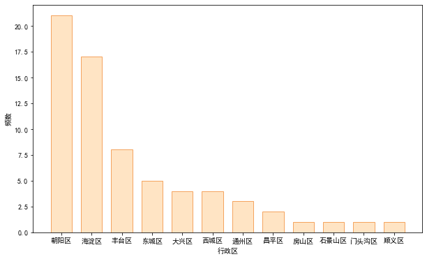

```python
area_cnt = xicha.groupby('adname')['name'].count()
area_cnt = pd.DataFrame({"area":area_cnt.index.tolist(), "cnt":area_cnt.values})
area_cnt = area_cnt.sort_values("cnt", ascending=False)
plt.figure(figsize=(10,6))
plt.bar(area_cnt["area"], area_cnt["cnt"],width = 0.7,
        color = 'bisque', edgecolor='sandybrown')
plt.xlabel('行政区')
plt.ylabel('频数')
```

```python
g = Map()
city = '北京'
g.add("喜茶店铺数", [list(z) for z in zip(area_cnt.area.tolist(), area_cnt.cnt.tolist())], city)
g.set_series_opts(label_opts=opts.LabelOpts(is_show=False))
pieces = [
        {'max': 2, 'label': '1家', 'color':  '#81AE9F'},
        {'min': 1, 'max': 5, 'label': '1-5', 'color': '#50A3BA'},
        {'min': 6, 'max': 10, 'label': '5-10', 'color': '#FCF84D'},
        {'min': 11, 'max': 20, 'label': '10-20', 'color': '#E2C568'},
        {'min': 20, 'label': '20以上', 'color':  '#DD675E'}  # 有下限无上限
    ]
g.set_global_opts(
        visualmap_opts=opts.VisualMapOpts(is_piecewise=True, pieces=pieces),
        title_opts=opts.TitleOpts(title="{}-喜茶店铺分布".format(city)),
    )

g.render(r'picture\area_render.html')
g.render_notebook()
```

### 解读参考：

北京市喜茶门店分布在12个区。店铺的区域分布非常不均匀，主要集中在朝阳区（21家）、海淀区（17家）、丰台区（8家）。这几个区位置较为中心，而且有着较多的学校、公司，常住人群相对年轻，是喜茶门店选址的热门区域。

## 任务三 喜茶门店的价格和评分情况

对北京喜茶门店的价格情况与评分情况进行描述分析。其中，价格情况用直方图表示，评分情况用柱形图表示。两张图都用matplotlib中的pyplot绘制，并通过参数设置颜色、横纵轴等信息。

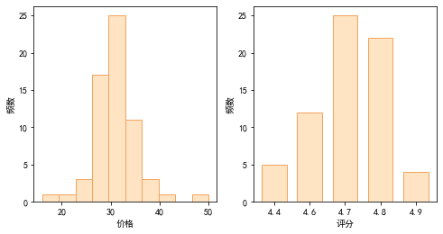

```python
## 价格分布
plt.figure(figsize=(8,4))
plt.subplot(1, 2, 1)
plt.hist(xicha['cost'],color = 'bisque', edgecolor='sandybrown')
plt.xlabel("价格")
plt.ylabel("频数")
## 评分分布
rating_cnt = xicha.groupby('rating')['name'].count()
rating_cnt = pd.DataFrame({"rating":rating_cnt.index.tolist(), "cnt":rating_cnt.values})
rating_cnt["rating"] = rating_cnt["rating"].map(lambda x:str(x))
plt.subplot(1, 2, 2)
plt.bar(rating_cnt["rating"], rating_cnt["cnt"],width = 0.7,
        color = 'bisque', edgecolor='sandybrown')
plt.xlabel('评分')
plt.ylabel('频数')
```

### 解读参考：

从价格看，喜茶的整体消费水平在人均30元左右。从评分看，北京市的喜茶门店评分整体较高，所有门店评分在4.4分以上，门店平均评分在4.7分左右。

## 任务四 POI分布情况

对北京喜茶门店的POI分布进行描述，主要从POI数、POI区域分布、POI行业分布三个方面入手。对于POI数，绘制直方图进行分析；对于POI区域分布，通过groupby函数进行分组统计，选取喜茶门店top-4的行政区（朝阳、海淀、丰台、东城），调用seaborn包，绘制分组箱线图。最后，根据POI所属的行业，统计不同行业POI占比，绘制饼图。

[output not shown]

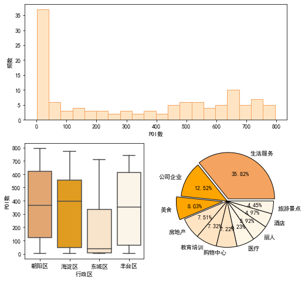

```python
## POI数分布
poi_cnt = poi.groupby(['store_name','area'])['name'].count().reset_index()
plt.figure(figsize=(8,8))
plt.subplot(2,1,1)
plt.hist(poi_cnt['name'],color = 'bisque', edgecolor='sandybrown',bins=20)
plt.xlabel("POI数")
plt.ylabel("频数")
## 区域分布
plt.subplot(2,2,3)
df_poi_boxplot = poi_cnt[poi_cnt['area'].isin(['海淀区','朝阳区','丰台区','东城区'])]
sns.boxplot(x='area', y='name', data=df_poi_boxplot, palette=['sandybrown','orange','bisque','oldlace'])
plt.xlabel('行政区')
plt.ylabel('POI数')
## 行业分布
plt.subplot(2,2,4)
shop_type = poi.groupby('type')['name'].count()
shop_type = pd.DataFrame({"type":list(shop_type.index),"cnt":shop_type.values})
shop_type = shop_type.sort_values('cnt',ascending=False)
shop_type['ratio'] = shop_type['cnt'] / sum(shop_type['cnt'] )
name_dict = {'beauty':'丽人','cater':'美食','education':'教育培训','enterprise':'公司企业',
             'hospital':'医疗','hotel':'酒店','house': '房地产','life':'生活服务','scope':'旅游景点','shopping':'购物中心'}
shop_type['name'] = shop_type['type'].map(name_dict)
colors = ('sandybrown','orange','orange','bisque','bisque','bisque','oldlace','oldlace','oldlace','oldlace')
plt.pie(shop_type['ratio'],labels = shop_type['name'],explode = [0.05,0,0.1,0,0,0,0,0,0,0],
        colors=colors,autopct='%1.2f%%',  wedgeprops={'linewidth': 1, 'edgecolor': "black"})
```

## 任务五 竞对协同分析

将餐饮POI中提供与喜茶同质但具有一定差异性的产品的POI，定义为喜茶的【竞对】，例如，咖啡厅、酒吧、茶座等POI。将餐饮POI中提供的产品类似喜茶产品的辅助者的POI，定义为喜茶的【协同】，例如，中餐厅、小吃快餐店、外国餐厅、蛋糕甜品店等POI。此处以【竞对】为例进行分析，从门店竞对数、竞对评分、价格、评论几个维度，对喜茶门店的竞对情况进行描述分析。

```python
## 设置POI一级分类餐饮中，二级分类为'咖啡厅','酒吧','茶座'的POI作为喜茶竞对
def split_tag_1(tag):
    if type(tag)==str:
        return tag.split(';')[0]
def split_tag_2(tag):
    if type(tag)==str:
        return tag.split(';')[-1]
poi['tag_detail_1'] = poi['tag'].map(split_tag_1)
poi['tag_detail_2'] = poi['tag'].map(split_tag_2)
competitor_industry = ['咖啡厅','酒吧','茶座']
competitor_poi = poi[poi['tag_detail_2'].isin(competitor_industry)]
store_list = poi['store_name'].unique()
competitor_poi_cnt = {}
for store in store_list:
    competitor_poi_cnt.setdefault(store,0)
    competitor_poi_cnt[store] += competitor_poi[competitor_poi['store_name']==store].shape[0]
competitor_poi_df = pd.DataFrame({"store_name":list(competitor_poi_cnt.keys()),"cnt":list(competitor_poi_cnt.values())})
competitor_poi_df = competitor_poi_df.sort_values("cnt", ascending=False)
competitor_poi_df.head()
```

|  | store_name | cnt |
| --- | --- | --- |
| 62 | 喜茶(北京三里屯太古里店) | 21 |
| 32 | 喜茶(北京清华东南门店) | 19 |
| 37 | 喜茶(北京翠微百货店) | 19 |
| 46 | 喜茶(远洋未来汇店) | 16 |
| 23 | 喜茶(北京丰台永旺店) | 16 |

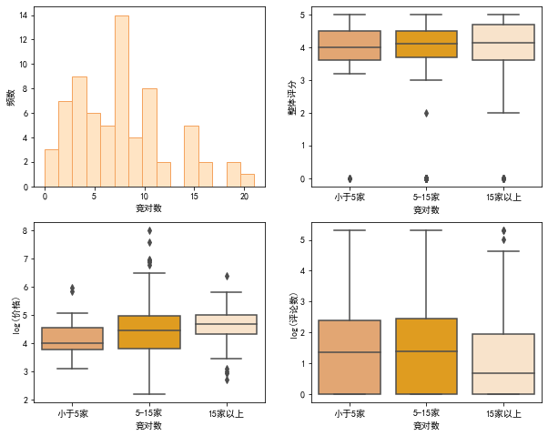

```python
def get_competitor_type(cnt):
    if cnt < 5:
        return '小于5家'
    elif cnt < 15:
        return '5-15家'
    else:
        return '15家以上'

competitor_poi_df['competitor_type'] = competitor_poi_df['cnt'].map(get_competitor_type)
competitor_poi_type_dict = dict(zip(competitor_poi_df['store_name'].values.tolist(),competitor_poi_df['competitor_type'].values.tolist()))
competitor_poi['competitor_type'] = competitor_poi['store_name'].map(competitor_poi_type_dict)
competitor_poi['competitor_type_sort'] = competitor_poi['competitor_type'].map({'小于5家':0,'5-15家':1,'15家以上':2})
competitor_poi = competitor_poi.sort_values("competitor_type_sort", ascending=True)

# 竞对数
plt.figure(figsize=(10,8))
plt.subplot(2,2,1)
price_fig = plt.hist(competitor_poi_df['cnt'],color = 'bisque', edgecolor='sandybrown',bins=15)
plt.xlabel("竞对数")
plt.ylabel("频数")
## 评分
plt.subplot(2,2,2)
sns.boxplot(x='competitor_type', y='overall_rating', data=competitor_poi, palette=['sandybrown','orange','bisque'])
plt.xlabel('竞对数')
plt.ylabel('整体评分')
## 价格
plt.subplot(2,2,3)
competitor_poi['price'] = competitor_poi['price'].map(lambda x:float(x))
competitor_poi['log_price'] = np.log(competitor_poi['price'].map(lambda x:float(x)))
sns.boxplot(x='competitor_type', y='log_price', data=competitor_poi.loc[~np.isnan(competitor_poi['price']),:], palette=['sandybrown','orange','bisque'])
plt.xlabel('竞对数')
plt.ylabel('log(价格)')
## 评论
plt.subplot(2,2,4)
competitor_poi['comment_num'] = competitor_poi['comment_num'].map(lambda x:float(x))
competitor_poi['log_comment_num'] = np.log(competitor_poi['comment_num'].map(lambda x:float(x))+1)
sns.boxplot(x='competitor_type', y='log_comment_num', data=competitor_poi.loc[~np.isnan(competitor_poi['comment_num']),:], palette=['sandybrown','orange','bisque'])
plt.xlabel('竞对数')
plt.ylabel('log(评论数)')
```

### 解读分析：

在竞对数上，多数门店的竞对数集中在5~15家（占比62%）。从评分/价格/评论数几个维度看，竞对的评分集中在4分左右，存在一定的竞争力；从价格看，竞对的人均消费价格呈现右偏长尾分布，主要集中在90元；从评论数看，竞对评论数差异非常大，约25%的竞对无评论。

## 任务六 经营优势分析

本案例定义一个新指标，用于衡量喜茶在线下的经营优势，具体指标定义如下：

**喜茶线下经营优势 = log(喜茶门店人流 / 门店周边POI平均人流)**

绘制这一指标的分布直方图与箱线图，对喜茶线下经营优势情况进行详细分析。

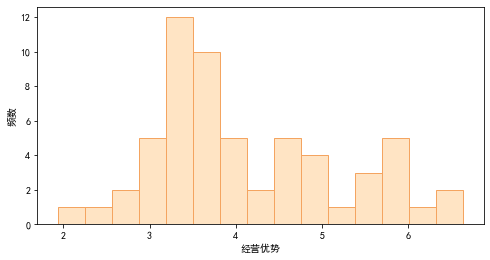

```python
##poi变量：poi数目，poi最多的行业，poi平均评分，poi平均评论数，poi平均价格，poi平均距离
def get_avg(all_list, is_price=False):
    price_list = []
    for price in all_list:
        if (is_price and pd.isna(price)==False and price.isdigit()) or (is_price==False and pd.isna(price)==False):
            if float(price) > 0:
                price_list.append(float(price))
    return np.mean(price_list)

store_name_list = xicha['name'].tolist()
poi_store_info = pd.DataFrame(columns=["name","poi_cnt","poi_max_tag","poi_rate_avg", "poi_comment_avg", "poi_price_avg", "poi_dist_avg"])
for name in store_name_list:
    temp_df = poi[poi['store_name']==name]
    poi_cnt = temp_df.shape[0]
    poi_max_tag = list(temp_df['tag_detail_1'].value_counts().sort_values(ascending=False).index)[0]
    poi_rate_avg = get_avg(temp_df['overall_rating'])
    poi_comment_avg = get_avg(temp_df['comment_num'])
    poi_price_avg = get_avg(temp_df['price'], True)
    poi_dist_avg = get_avg(temp_df['distance'])
    temp_dict = {"name":name,"poi_cnt":poi_cnt,"poi_max_tag":poi_max_tag,"poi_rate_avg":poi_rate_avg, "poi_comment_avg":poi_comment_avg, "poi_price_avg":poi_price_avg, "poi_dist_avg":poi_dist_avg}
    poi_store_info = poi_store_info.append(temp_dict, ignore_index=True)
xicha_all = pd.merge(xicha[['name','adname','cost', 'rating','comments_num']], poi_store_info, on = 'name')
xicha_all['comments_num'] = xicha_all['comments_num'].fillna(np.median(xicha_all['comments_num']))
##新指标定义
xicha_all['comments_num_diff'] = xicha_all['comments_num']  / xicha_all['poi_comment_avg']
xicha_all_plot = xicha_all.dropna()
xicha_all_plot['log_comments_num_diff'] =  np.log(xicha_all_plot['comments_num_diff'])
plt.figure(figsize=(8,4))
price_fig = plt.hist(xicha_all_plot['log_comments_num_diff'],color = 'bisque', edgecolor='sandybrown',bins=15)
plt.xlabel("经营优势")
plt.ylabel("频数")
```

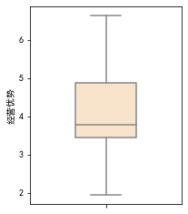

```python
plt.figure(figsize=(3,4))
sns.boxplot(y='log_comments_num_diff', data=xicha_all_plot, palette=['bisque'],width=0.4)
plt.xlabel('')
plt.ylabel('经营优势')
```

### 解读分析：

喜茶在周边POI中相对经营状况较好，人流数基本高于周边POI的平均人流。而各个门店的经营状况则差异较大。多数门店的经营优势集中在3~4，而少数门店经营相当有优势，经营优势超过了6。

## 任务七 聚类分析

根据喜茶门店经营信息，以及喜茶周边POI信息聚合，调用KMeans包，对全北京的喜茶门店进行K-means聚类，将门店聚为3类。需要注意的是，在聚类之前，最好先对数据进行标准化处理，聚类效果会好一些。完成聚类后，根据聚类结果，调用pychart包，绘制聚类结果分布地图。

```python
# 去除na,防止聚类失败
xicha_all['cost'] = xicha_all['cost'].fillna(np.mean(xicha_all['cost']))
xicha_all['rating'] = xicha_all['rating'].fillna(np.mean(xicha_all['rating']))
xicha_all['poi_cnt'] = xicha_all['poi_cnt'].fillna(np.mean(xicha_all['poi_cnt']))
xicha_all['poi_rate_avg'] = xicha_all['poi_rate_avg'].fillna(np.mean(xicha_all['poi_rate_avg']))
xicha_all['poi_comment_avg'] = xicha_all['poi_comment_avg'].fillna(np.mean(xicha_all['poi_comment_avg']))
xicha_all['poi_dist_avg'] = xicha_all['poi_dist_avg'].fillna(np.mean(xicha_all['poi_dist_avg']))
xicha_all['poi_price_avg'] = xicha_all['poi_price_avg'].fillna(np.mean(xicha_all['poi_price_avg']))
xicha_df_cluster = xicha_all[['cost','rating','poi_cnt','poi_rate_avg','poi_comment_avg','poi_price_avg','poi_dist_avg']].values
## 标准化处理
xicha_df_cluster = (xicha_df_cluster-np.mean(xicha_df_cluster, axis=0))/np.std(xicha_df_cluster, axis=0)
## kmeans聚类
cluster_res = KMeans(n_clusters=3, random_state=1234).fit(xicha_df_cluster)
xicha_all['cluster'] = cluster_res.labels_
def get_cluster(label):
    if label==0:
        return "类别 1"
    if label==1:
        return "类别 2"
    if label==2:
        return "类别 3"
xicha_all['cluster'] = xicha_all['cluster'].map(get_cluster)
xicha_all = xicha_all.sort_values("cluster")
```

```python
## 绘制地图
xicha_df_location = pd.merge(xicha_all, xicha[['name','location']], on = 'name')
xicha_df_location['lng'] = xicha_df_location['location'].map(lambda x:float(x.split(',')[0]))
xicha_df_location['lat'] = xicha_df_location['location'].map(lambda x:float(x.split(',')[1]))
g = Geo().add_schema(maptype="北京")
xicha_df_location_1 = xicha_df_location[xicha_df_location['cluster']=='类别 1']
xicha_df_location_2 = xicha_df_location[xicha_df_location['cluster']=='类别 2']
xicha_df_location_3 = xicha_df_location[xicha_df_location['cluster']=='类别 3']
for idx in range(len(xicha_df_location_1)):
    g.add_coordinate(1, xicha_df_location_1.lng.iloc[idx], xicha_df_location_1.lat.iloc[idx])
    g.add(series_name='类别 1',  data_pair=[(1,1)],symbol_size=8)#
for idx in range(len(xicha_df_location_2)):
    g.add_coordinate(2, xicha_df_location_2.lng.iloc[idx], xicha_df_location_2.lat.iloc[idx])
    g.add(series_name='类别 2',  data_pair=[(2,2)],symbol_size=8)#
for idx in range(len(xicha_df_location_3)):
    g.add_coordinate(3, xicha_df_location_3.lng.iloc[idx], xicha_df_location_3.lat.iloc[idx])
    g.add(series_name='类别 3',  data_pair=[(3,3)],symbol_size=8)#
g.set_series_opts(visualmap_opts=opts.VisualMapOpts(is_show=True),label_opts=opts.LabelOpts(is_show=False),
                  title_opts=opts.TitleOpts(title="喜茶店铺聚类分布"))

g.render(r'picture\area_cluster_render.html')
g.render_notebook()
```

## 任务八 基于聚类结果的分析

对聚类结果进行描述分析。主要从POI数、POI评分、POI人流、POI价格、POI距离、竞争优势几个维度进行分析，绘制各个指标的分组箱线图。根据箱线图结果，可以发现，不同类别的门店在各个属性上有一定差异，聚类确实将门店区分开了。

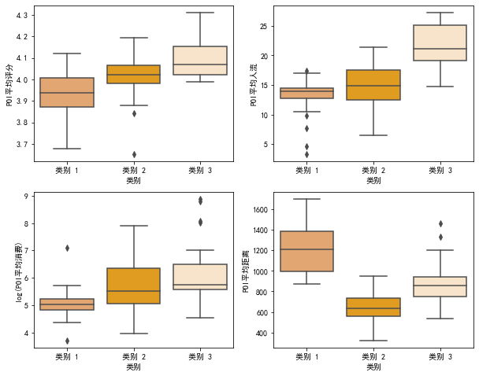

```python
## 平均评分
plt.figure(figsize=(10,8))
plt.subplot(2,2,1)
sns.boxplot(x='cluster', y='poi_rate_avg', data=xicha_all, palette=['sandybrown','orange','bisque'])
plt.xlabel('类别')
plt.ylabel('POI平均评分')
## 平均人流
plt.subplot(2,2,2)
sns.boxplot(x='cluster', y='poi_comment_avg', data=xicha_all, palette=['sandybrown','orange','bisque'])
plt.xlabel('类别')
plt.ylabel('POI平均人流')
## 平均消费
xicha_all['log_poi_price_avg'] = np.log(xicha_all['poi_price_avg'].map(lambda x:float(x))+1)
plt.subplot(2,2,3)
sns.boxplot(x='cluster', y='log_poi_price_avg', data=xicha_all, palette=['sandybrown','orange','bisque'])
plt.xlabel('类别')
plt.ylabel('log(POI平均消费)')
## 平均距离
plt.subplot(2,2,4)
sns.boxplot(x='cluster', y='poi_dist_avg', data=xicha_all, palette=['sandybrown','orange','bisque'])
plt.xlabel('类别')
plt.ylabel('POI平均距离')
```

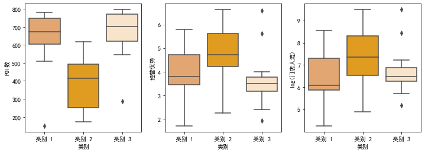

```python
## POI数
plt.figure(figsize=(12,4))
plt.subplot(1,3,1)
sns.boxplot(x='cluster', y='poi_cnt', data=xicha_all, palette=['sandybrown','orange','bisque'])
plt.xlabel('类别')
plt.ylabel('POI数')
## 经营优势
plt.subplot(1,3,2)
xicha_all['log_comments_num_diff'] =  np.log(xicha_all['comments_num_diff'])
sns.boxplot(x='cluster', y='log_comments_num_diff', data=xicha_all, palette=['sandybrown','orange','bisque'])
plt.xlabel('类别')
plt.ylabel('经营优势')
## 人流
plt.subplot(1,3,3)
xicha_all['log_comments_num'] =  np.log(xicha_all['comments_num'])
sns.boxplot(x='cluster', y='log_comments_num', data=xicha_all, palette=['sandybrown','orange','bisque'])
plt.xlabel('类别')
plt.ylabel('log(门店人流)')
```